# Linear Regression

Priyanshu Agarwal

12/04/2020

Linear regression is used to predict the value of an outcome variable Y based on one or more input predictor variables X. The aim is to establish a linear relationship (a mathematical formula) between the predictor variable(s) and the response variable, so that, we can use this formula to estimate the value of the response Y, when only the predictors (Xs) values are known.https://www.datanovia.com/en/lessons/identify-and-remove-duplicate-data-in-r/

We’ll first have to import our datasiet. For this project we are taking dataset from [Kaggle].

Github Link : https://github.com/prinzz1208/acad-DS-LinearRegression/blob/master/car%20data.csv

```r
dataSet = read.csv("/home/prinzz1208/Desktop/Work/Data Science/R/car data.csv",header = TRUE)
head(dataSet)
```

```
##        Car_Name Year Selling_Price Present_Price Kms_Driven Fuel_Type
## 1          ritz 2014          3.35          5.59      27000    Petrol
## 2           sx4 2013          4.75          9.54      43000    Diesel
## 3          ciaz 2017          7.25          9.85       6900    Petrol
## 4       wagon r 2011          2.85          4.15       5200    Petrol
## 5         swift 2014          4.60          6.87      42450    Diesel
## 6 vitara brezza 2018          9.25          9.83       2071    Diesel
##   Seller_Type Transmission Owner
## 1      Dealer       Manual     0
## 2      Dealer       Manual     0
## 3      Dealer       Manual     0
## 4      Dealer       Manual     0
## 5      Dealer       Manual     0
## 6      Dealer       Manual     0
```

The dataset which we are going to use has data about cars. It consists of 301 rows and 9 columns.

We will first check for NA elements in our data set.

```r
mean(is.na(dataSet))
```

```
## [1] 0
```

If we had even one NA element in our data set the mean would be a non-zero element and hence we don’t have to check further for any NA element in any row or column.

Beacause the mean of is.na(dataSet) is 0 we can say that our data set does not contain any NA value.

Now to remove any duplicate we will use distinct function of dplyr library to remove all duplicate rows, if any.

```r
library(dplyr)
dataSet = distinct(dataSet)
```

To see the distribution of data between variables we will use ggpairs() function from GGally library.

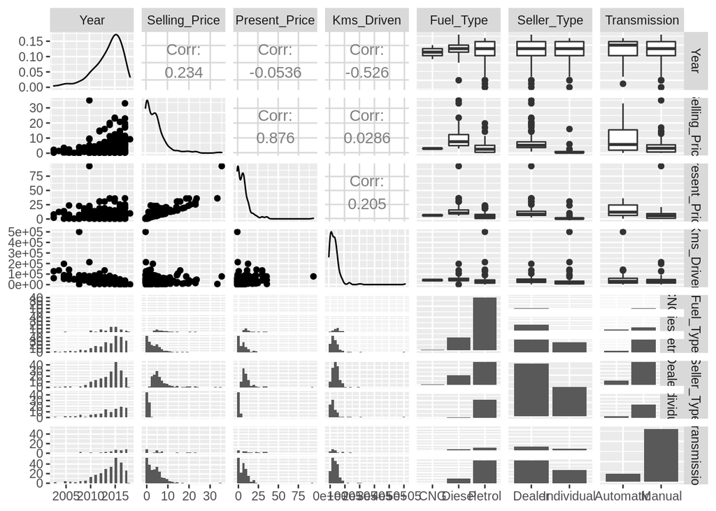

```r
library(GGally)
ggpairs(dataSet,columns = 2:8)
```

We can see that our dataset also contains catagorial data (because of box plot instead of correlation) which we will ignore as we don’t want catagorial data for prediction.

Now we’ll check the correlation of variables to get our predictor variables.

```r
cor(dataSet$Present_Price,dataSet$Selling_Price)
```

```
## [1] 0.8763782
```

```r
cor(dataSet$Year,dataSet$Selling_Price)
```

```
## [1] 0.2343694
```

```r
cor(dataSet$Kms_Driven,dataSet$Selling_Price)
```

```
## [1] 0.02856559
```

From the result above we can say that Present Price and Selling Price have a very strong correlation but Kms_Driven and Year have a weak correlation with Selling Price although they can be used to in linear model but won’t have much significance.

Now we’ll plot our data using a scatter plot.

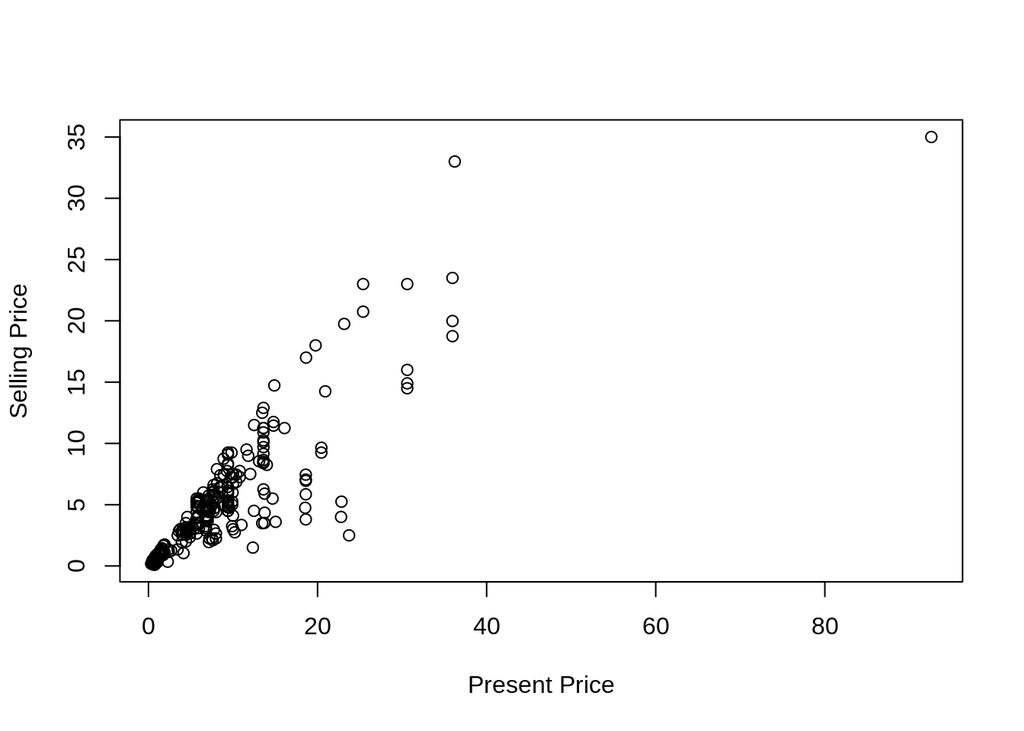

```r
plot(dataSet$Present_Price,dataSet$Selling_Price,xlab = 'Present Price',ylab = 'Selling Price')
```

We can see from this scatter plot that there is a linear relationship between the predictor variable(Present Price) and response variable(Selling Price) which is good because one of the underlying assumptions in linear regression is that the relationship between the response and predictor variables is linear and additive.

Now for our prediction model we first have to devise a linear model. We will have to try different linear models and plot it against the predictor variable so that we could check if our model is correct for regression.

First model:

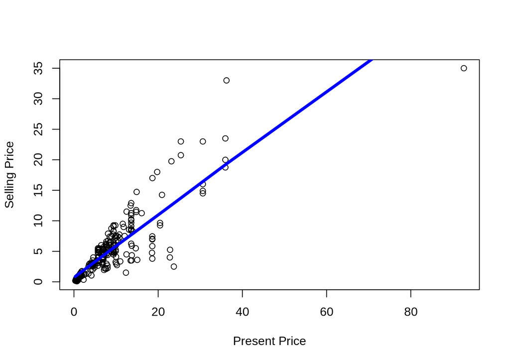

```r
plot(dataSet$Present_Price,dataSet$Selling_Price,xlab = 'Present Price',ylab = 'Selling Price')
model = lm(Selling_Price ~ Present_Price + Kms_Driven + Year, data = dataSet )
lines(smooth.spline(dataSet$Present_Price,predict(model)),col = 'blue',lwd = '4')
```

From the plot, we can see that our model has problem of *Underfitting*.

We can also check the accuracy of from its summary.

```r
summary(model)
```

```
##
## Call:
## lm(formula = Selling_Price ~ Present_Price + Kms_Driven + Year,
##     data = dataSet)
##
## Residuals:
##      Min       1Q   Median       3Q      Max
## -12.0067  -0.9678  -0.0598   0.8047  11.8546
##
## Coefficients:
##                 Estimate Std. Error t value Pr(>|t|)
## (Intercept)   -9.609e+02  9.287e+01 -10.347   <2e-16 ***
## Present_Price  5.195e-01  1.355e-02  38.355   <2e-16 ***
## Kms_Driven    -1.126e-06  3.492e-06  -0.322    0.747
## Year           4.776e-01  4.609e-02  10.361   <2e-16 ***
## ---
## Signif. codes:  0 '***' 0.001 '**' 0.01 '*' 0.05 '.' 0.1 ' ' 1
##
## Residual standard error: 1.957 on 295 degrees of freedom
## Multiple R-squared:  0.8475, Adjusted R-squared:  0.8459
## F-statistic: 546.3 on 3 and 295 DF,  p-value: < 2.2e-16
```

From the summary we can see that our Residual standard error is near 2, which is not good as residual standard error is the measure of the variation of observations around the regression line. So to reduce this error we’ll need to change our model.

Second Model:

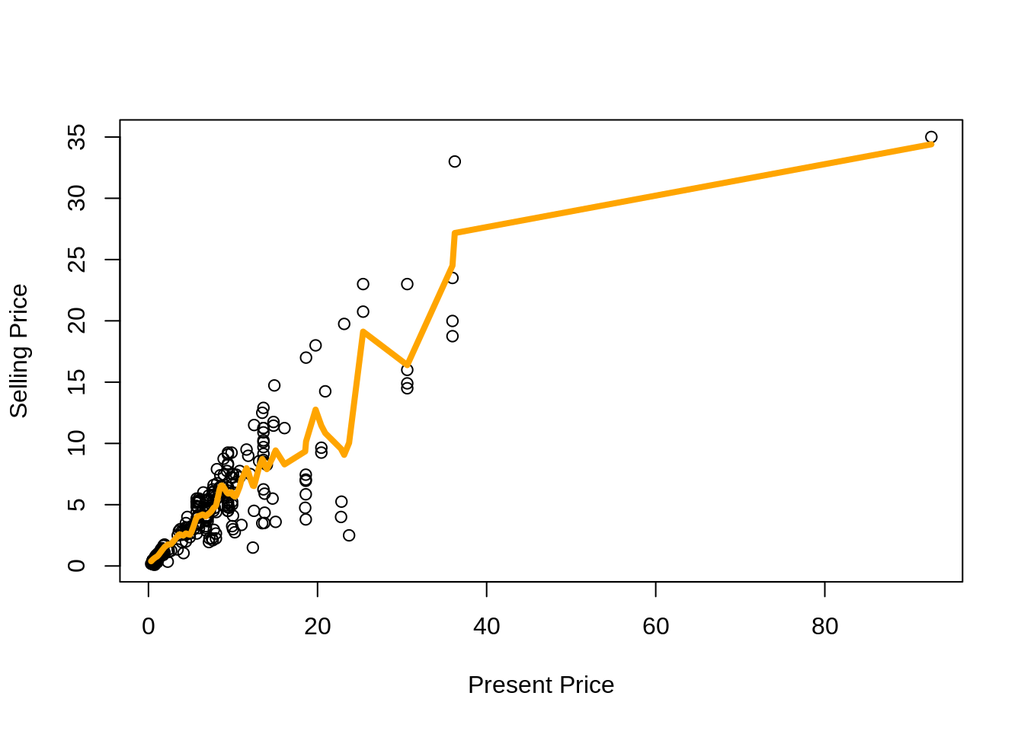

```r
plot(dataSet$Present_Price,dataSet$Selling_Price,xlab = 'Present Price',ylab = 'Selling Price')
model2 = lm(Selling_Price ~ poly(Present_Price,Year,Kms_Driven,degree = 2,raw = TRUE), data = dataSet )
lines(smooth.spline(dataSet$Present_Price,predict(model2)),col = 'orange',lwd = '4')
```

From the plot we can say that it looks better than our previous model and it has also removed the problem of underfitting.

Now to check accuracy:

```r
summary(model2)
```

```
##
## Call:
## lm(formula = Selling_Price ~ poly(Present_Price, Year, Kms_Driven,
##     degree = 2, raw = TRUE), data = dataSet)
##
## Residuals:
##     Min      1Q  Median      3Q     Max
## -3.3802 -0.3644 -0.0772  0.4664  3.1594
##
## Coefficients:
##                                                                      Estimate
## (Intercept)                                                         7.782e+04
## poly(Present_Price, Year, Kms_Driven, degree = 2, raw = TRUE)1.0.0 -1.343e+02
## poly(Present_Price, Year, Kms_Driven, degree = 2, raw = TRUE)2.0.0  5.532e-04
## poly(Present_Price, Year, Kms_Driven, degree = 2, raw = TRUE)0.1.0 -7.737e+01
## poly(Present_Price, Year, Kms_Driven, degree = 2, raw = TRUE)1.1.0  6.700e-02
## poly(Present_Price, Year, Kms_Driven, degree = 2, raw = TRUE)0.2.0  1.923e-02
## poly(Present_Price, Year, Kms_Driven, degree = 2, raw = TRUE)0.0.1  2.381e-03
## poly(Present_Price, Year, Kms_Driven, degree = 2, raw = TRUE)1.0.1 -7.021e-07
## poly(Present_Price, Year, Kms_Driven, degree = 2, raw = TRUE)0.1.1 -1.181e-06
## poly(Present_Price, Year, Kms_Driven, degree = 2, raw = TRUE)0.0.2 -1.568e-11
##                                                                    Std. Error
## (Intercept)                                                         2.993e+04
## poly(Present_Price, Year, Kms_Driven, degree = 2, raw = TRUE)1.0.0  7.054e+00
## poly(Present_Price, Year, Kms_Driven, degree = 2, raw = TRUE)2.0.0  2.256e-04
## poly(Present_Price, Year, Kms_Driven, degree = 2, raw = TRUE)0.1.0  2.973e+01
## poly(Present_Price, Year, Kms_Driven, degree = 2, raw = TRUE)1.1.0  3.498e-03
## poly(Present_Price, Year, Kms_Driven, degree = 2, raw = TRUE)0.2.0  7.382e-03
## poly(Present_Price, Year, Kms_Driven, degree = 2, raw = TRUE)0.0.1  1.759e-03
## poly(Present_Price, Year, Kms_Driven, degree = 2, raw = TRUE)1.0.1  2.714e-07
## poly(Present_Price, Year, Kms_Driven, degree = 2, raw = TRUE)0.1.1  8.737e-07
## poly(Present_Price, Year, Kms_Driven, degree = 2, raw = TRUE)0.0.2  1.235e-11
##                                                                    t value
## (Intercept)                                                          2.600
## poly(Present_Price, Year, Kms_Driven, degree = 2, raw = TRUE)1.0.0 -19.037
## poly(Present_Price, Year, Kms_Driven, degree = 2, raw = TRUE)2.0.0   2.452
## poly(Present_Price, Year, Kms_Driven, degree = 2, raw = TRUE)0.1.0  -2.602
## poly(Present_Price, Year, Kms_Driven, degree = 2, raw = TRUE)1.1.0  19.151
## poly(Present_Price, Year, Kms_Driven, degree = 2, raw = TRUE)0.2.0   2.605
## poly(Present_Price, Year, Kms_Driven, degree = 2, raw = TRUE)0.0.1   1.353
## poly(Present_Price, Year, Kms_Driven, degree = 2, raw = TRUE)1.0.1  -2.587
## poly(Present_Price, Year, Kms_Driven, degree = 2, raw = TRUE)0.1.1  -1.352
## poly(Present_Price, Year, Kms_Driven, degree = 2, raw = TRUE)0.0.2  -1.269
##                                                                    Pr(>|t|)
## (Intercept)                                                         0.00981 **
## poly(Present_Price, Year, Kms_Driven, degree = 2, raw = TRUE)1.0.0  < 2e-16 ***
## poly(Present_Price, Year, Kms_Driven, degree = 2, raw = TRUE)2.0.0  0.01478 *
## poly(Present_Price, Year, Kms_Driven, degree = 2, raw = TRUE)0.1.0  0.00974 **
## poly(Present_Price, Year, Kms_Driven, degree = 2, raw = TRUE)1.1.0  < 2e-16 ***
## poly(Present_Price, Year, Kms_Driven, degree = 2, raw = TRUE)0.2.0  0.00967 **
## poly(Present_Price, Year, Kms_Driven, degree = 2, raw = TRUE)0.0.1  0.17696
## poly(Present_Price, Year, Kms_Driven, degree = 2, raw = TRUE)1.0.1  0.01017 *
## poly(Present_Price, Year, Kms_Driven, degree = 2, raw = TRUE)0.1.1  0.17738
## poly(Present_Price, Year, Kms_Driven, degree = 2, raw = TRUE)0.0.2  0.20530
## ---
## Signif. codes:  0 '***' 0.001 '**' 0.01 '*' 0.05 '.' 0.1 ' ' 1
##
## Residual standard error: 0.911 on 289 degrees of freedom
## Multiple R-squared:  0.9676, Adjusted R-squared:  0.9666
## F-statistic:   959 on 9 and 289 DF,  p-value: < 2.2e-16
```

Third Model:

Now we’ll try to fit a polynomial model with 3 variables with maximum degree 4 to remove the underfitting problem.

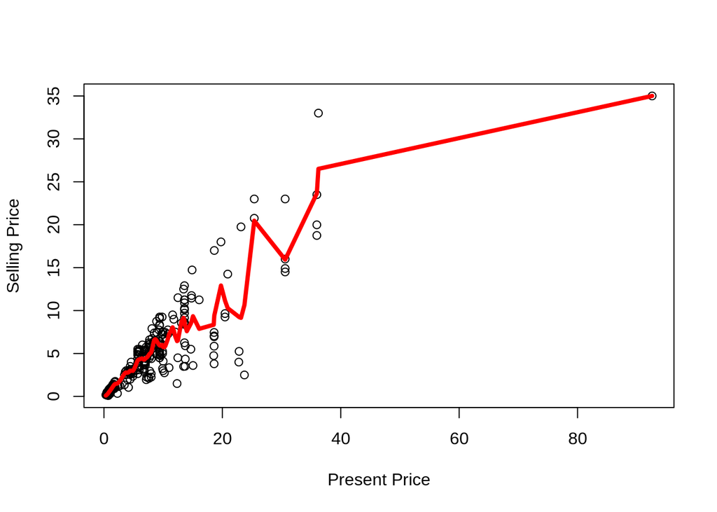

```r
plot(dataSet$Present_Price,dataSet$Selling_Price,xlab = 'Present Price',ylab = 'Selling Price')
model3 = lm(Selling_Price ~ poly(Present_Price,Year,Kms_Driven,degree = 4,raw = TRUE), data = dataSet )
lines(smooth.spline(dataSet$Present_Price,predict(model3)),col = 'red',lwd = '4')
```

From the plot we can say that there is a slight different between the second model and third and third model fits better but we can also see that it overfits the data and hence has problem of overfitting so we will reject this highly complicated model.

So our selected model is second model, And we can start training our model and perform predictions.

```r
ind = sample(2,nrow(dataSet),replace = TRUE,prob = c(0.7,0.3))
trainingData = dataSet[ind == 1,]
testData = dataSet[ind == 2,]
```

We have separated out our data and now we have to train our model.

```r
mod = lm(Selling_Price ~ poly(Present_Price,Year,Kms_Driven,degree = 2,raw = T),trainingData)
```

Now we will predict the values for Selling Price with our model.

```r
pred = cbind(predict(mod,testData))
compare = unname(data.frame(pred,testData[3]))
colnames(compare) = c("Predicted","Actual")
head(compare,10)
```

```
##    Predicted Actual
## 3   8.675458   7.25
## 5   4.222641   4.60
## 7   5.733832   6.75
## 8   6.004206   6.50
## 12  7.127248   6.85
## 13  7.033138   7.50
## 17  7.469784   7.25
## 18  3.556763   3.25
## 19  2.937330   2.65
## 21  5.207568   4.90
```

Our predictions are not much accurate but they are acceptable.

Now to check the accuracy of our model we’ll find Root Mean Square Error (RMSE) and Mean Absolute Error (MAE).

We’ll use caret package for in-built RMSE and MAE functions.

```r
library(caret)
MAE(predict(mod,testData),testData$Selling_Price)
```

```
## [1] 0.5241543
```

```r
RMSE(predict(mod,testData),testData$Selling_Price)
```

```
## [1] 0.82477
```

The result of MAE and RMSE are fine and hence the prediction model is acceptably accurate.

Github link for the project : https://github.com/prinzz1208/acad-DS-LinearRegression.git